# Risk Factor Analysis

## Outcome Variable

**Outcome Variable:** wast_rec90d

## Predictor Variables

**Intervention Variable:** hdlvry

**Adjustment Set:**

unadjusted

## Stratifying Variables

The analysis was stratified on these variable(s):

- agecat
- studyid
- country

## Data Summary

| agecat | studyid | country | hdlvry | wast_rec90d | n_cell | n |
| --- | --- | --- | --- | --- | --- | --- |
| 0-24 months | ki1000108-CMC-V-BCS-2002 | INDIA | 0 | 0 | 115 | 322 |
| 0-24 months | ki1000108-CMC-V-BCS-2002 | INDIA | 0 | 1 | 200 | 322 |
| 0-24 months | ki1000108-CMC-V-BCS-2002 | INDIA | 1 | 0 | 4 | 322 |
| 0-24 months | ki1000108-CMC-V-BCS-2002 | INDIA | 1 | 1 | 3 | 322 |
| 0-24 months | ki1000108-IRC | INDIA | 0 | 0 | 159 | 395 |
| 0-24 months | ki1000108-IRC | INDIA | 0 | 1 | 227 | 395 |
| 0-24 months | ki1000108-IRC | INDIA | 1 | 0 | 3 | 395 |
| 0-24 months | ki1000108-IRC | INDIA | 1 | 1 | 6 | 395 |
| 0-24 months | ki1000109-EE | PAKISTAN | 0 | 0 | 97 | 255 |
| 0-24 months | ki1000109-EE | PAKISTAN | 0 | 1 | 72 | 255 |
| 0-24 months | ki1000109-EE | PAKISTAN | 1 | 0 | 51 | 255 |
| 0-24 months | ki1000109-EE | PAKISTAN | 1 | 1 | 35 | 255 |
| 0-24 months | ki1000304b-SAS-CompFeed | INDIA | 0 | 0 | 34 | 675 |
| 0-24 months | ki1000304b-SAS-CompFeed | INDIA | 0 | 1 | 30 | 675 |
| 0-24 months | ki1000304b-SAS-CompFeed | INDIA | 1 | 0 | 386 | 675 |
| 0-24 months | ki1000304b-SAS-CompFeed | INDIA | 1 | 1 | 225 | 675 |
| 0-24 months | ki1000304b-SAS-FoodSuppl | INDIA | 0 | 0 | 40 | 234 |
| 0-24 months | ki1000304b-SAS-FoodSuppl | INDIA | 0 | 1 | 0 | 234 |
| 0-24 months | ki1000304b-SAS-FoodSuppl | INDIA | 1 | 0 | 181 | 234 |
| 0-24 months | ki1000304b-SAS-FoodSuppl | INDIA | 1 | 1 | 13 | 234 |
| 0-24 months | ki1017093b-PROVIDE | BANGLADESH | 0 | 0 | 94 | 307 |
| 0-24 months | ki1017093b-PROVIDE | BANGLADESH | 0 | 1 | 132 | 307 |
| 0-24 months | ki1017093b-PROVIDE | BANGLADESH | 1 | 0 | 34 | 307 |
| 0-24 months | ki1017093b-PROVIDE | BANGLADESH | 1 | 1 | 47 | 307 |
| 0-24 months | ki1017093c-NIH-Crypto | BANGLADESH | 0 | 0 | 79 | 311 |
| 0-24 months | ki1017093c-NIH-Crypto | BANGLADESH | 0 | 1 | 139 | 311 |
| 0-24 months | ki1017093c-NIH-Crypto | BANGLADESH | 1 | 0 | 38 | 311 |
| 0-24 months | ki1017093c-NIH-Crypto | BANGLADESH | 1 | 1 | 55 | 311 |
| 0-24 months | ki1066203-TanzaniaChild2 | TANZANIA, UNITED REPUBLIC OF | 0 | 0 | 250 | 682 |
| 0-24 months | ki1066203-TanzaniaChild2 | TANZANIA, UNITED REPUBLIC OF | 0 | 1 | 423 | 682 |

[output cut: 114 more lines]

The following strata were considered:

- agecat: 0-24 months, studyid: ki1000108-CMC-V-BCS-2002, country: INDIA
- agecat: 0-24 months, studyid: ki1000108-IRC, country: INDIA
- agecat: 0-24 months, studyid: ki1000109-EE, country: PAKISTAN
- agecat: 0-24 months, studyid: ki1000304b-SAS-CompFeed, country: INDIA
- agecat: 0-24 months, studyid: ki1000304b-SAS-FoodSuppl, country: INDIA
- agecat: 0-24 months, studyid: ki1017093b-PROVIDE, country: BANGLADESH
- agecat: 0-24 months, studyid: ki1017093c-NIH-Crypto, country: BANGLADESH
- agecat: 0-24 months, studyid: ki1066203-TanzaniaChild2, country: TANZANIA, UNITED REPUBLIC OF
- agecat: 0-24 months, studyid: ki1113344-GMS-Nepal, country: NEPAL
- agecat: 0-24 months, studyid: ki1135781-COHORTS, country: INDIA
- agecat: 0-24 months, studyid: kiGH5241-JiVitA-3, country: BANGLADESH
- agecat: 0-24 months, studyid: kiGH5241-JiVitA-4, country: BANGLADESH
- agecat: 0-6 months, studyid: ki1000108-CMC-V-BCS-2002, country: INDIA
- agecat: 0-6 months, studyid: ki1000108-IRC, country: INDIA
- agecat: 0-6 months, studyid: ki1000109-EE, country: PAKISTAN
- agecat: 0-6 months, studyid: ki1000304b-SAS-CompFeed, country: INDIA
- agecat: 0-6 months, studyid: ki1000304b-SAS-FoodSuppl, country: INDIA
- agecat: 0-6 months, studyid: ki1017093b-PROVIDE, country: BANGLADESH
- agecat: 0-6 months, studyid: ki1017093c-NIH-Crypto, country: BANGLADESH
- agecat: 0-6 months, studyid: ki1066203-TanzaniaChild2, country: TANZANIA, UNITED REPUBLIC OF
- agecat: 0-6 months, studyid: ki1113344-GMS-Nepal, country: NEPAL
- agecat: 0-6 months, studyid: ki1135781-COHORTS, country: INDIA
- agecat: 0-6 months, studyid: kiGH5241-JiVitA-3, country: BANGLADESH
- agecat: 0-6 months, studyid: kiGH5241-JiVitA-4, country: BANGLADESH
- agecat: 6-24 months, studyid: ki1000108-CMC-V-BCS-2002, country: INDIA
- agecat: 6-24 months, studyid: ki1000108-IRC, country: INDIA
- agecat: 6-24 months, studyid: ki1000109-EE, country: PAKISTAN
- agecat: 6-24 months, studyid: ki1000304b-SAS-CompFeed, country: INDIA
- agecat: 6-24 months, studyid: ki1000304b-SAS-FoodSuppl, country: INDIA
- agecat: 6-24 months, studyid: ki1017093b-PROVIDE, country: BANGLADESH
- agecat: 6-24 months, studyid: ki1017093c-NIH-Crypto, country: BANGLADESH
- agecat: 6-24 months, studyid: ki1066203-TanzaniaChild2, country: TANZANIA, UNITED REPUBLIC OF
- agecat: 6-24 months, studyid: ki1113344-GMS-Nepal, country: NEPAL
- agecat: 6-24 months, studyid: ki1135781-COHORTS, country: INDIA
- agecat: 6-24 months, studyid: kiGH5241-JiVitA-3, country: BANGLADESH
- agecat: 6-24 months, studyid: kiGH5241-JiVitA-4, country: BANGLADESH

### Dropped Strata

Some strata were dropped due to rare outcomes:

- agecat: 0-24 months, studyid: ki1000108-CMC-V-BCS-2002, country: INDIA
- agecat: 0-24 months, studyid: ki1000108-IRC, country: INDIA
- agecat: 0-24 months, studyid: ki1000304b-SAS-FoodSuppl, country: INDIA
- agecat: 0-24 months, studyid: ki1066203-TanzaniaChild2, country: TANZANIA, UNITED REPUBLIC OF
- agecat: 0-6 months, studyid: ki1000108-CMC-V-BCS-2002, country: INDIA
- agecat: 0-6 months, studyid: ki1000108-IRC, country: INDIA
- agecat: 0-6 months, studyid: ki1000304b-SAS-FoodSuppl, country: INDIA
- agecat: 0-6 months, studyid: ki1066203-TanzaniaChild2, country: TANZANIA, UNITED REPUBLIC OF
- agecat: 0-6 months, studyid: kiGH5241-JiVitA-3, country: BANGLADESH
- agecat: 6-24 months, studyid: ki1000108-CMC-V-BCS-2002, country: INDIA
- agecat: 6-24 months, studyid: ki1000108-IRC, country: INDIA
- agecat: 6-24 months, studyid: ki1000304b-SAS-FoodSuppl, country: INDIA
- agecat: 6-24 months, studyid: ki1017093c-NIH-Crypto, country: BANGLADESH
- agecat: 6-24 months, studyid: ki1066203-TanzaniaChild2, country: TANZANIA, UNITED REPUBLIC OF
- agecat: 6-24 months, studyid: ki1135781-COHORTS, country: INDIA
- agecat: 6-24 months, studyid: kiGH5241-JiVitA-3, country: BANGLADESH

## Methods Detail

We’re interested in the causal parameters $E[Y_a]$ for all values of $a \in \mathcal{A}$. These parameters represent the mean outcome if, possibly contrary to fact, we intervened to set all units to have $A=a$. Under the randomization and positivity assumptions, these are identified by the statistical parameters $\psi_a=E_W[E_{Y|A,W}(Y|A=a,W)]$. In addition, we’re interested in the mean of $Y$, $E[Y]$ under no intervention (the observed mean). We will estimate these parameters by using SuperLearner to fit the relevant likelihood factors – $E_{Y|A,W}(Y|A=a,W)$ and $p(A=a|W)$, and then updating our likelihood fit using a joint TMLE.

For unadjusted analyses ($W=\{\}$), initial likelihoods were estimated using Lrnr_glm to estimate the simple $E(Y|A)$ and Lrnr_mean to estimate $p(A)$. For adjusted analyses, a small library containing Lrnr_glmnet, Lrnr_xgboost, and Lrnr_mean was used.

Having estimated these parameters, we will then use the delta method to estimate relative risks and attributable risks relative to a prespecified baseline level of $A$.

# Results Detail

## Results Plots

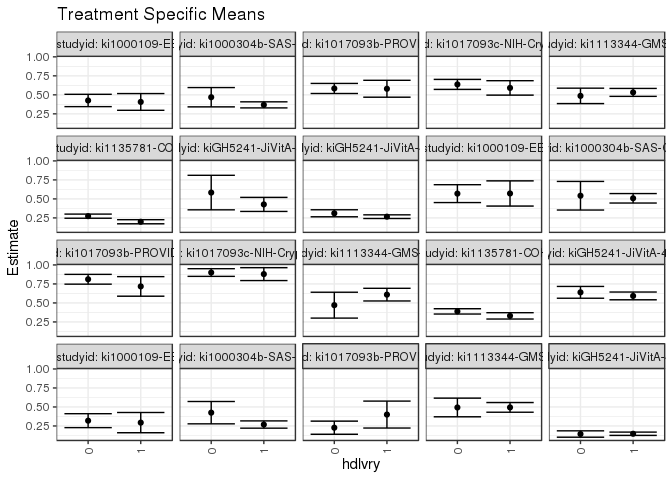

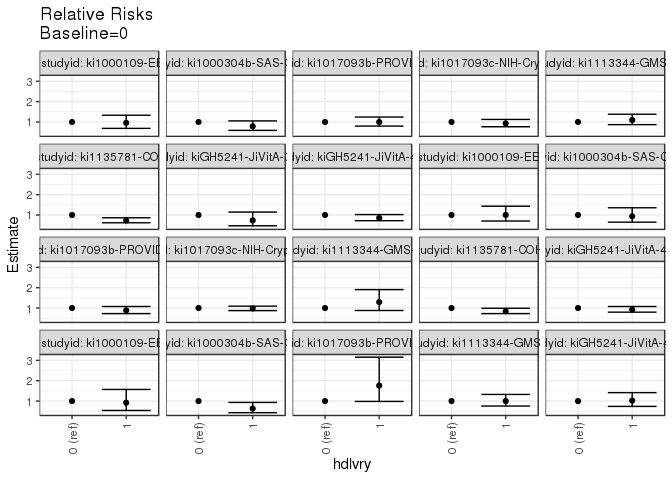

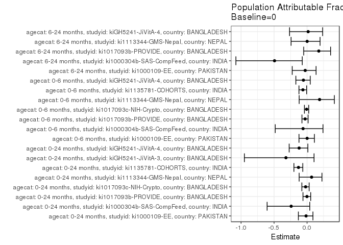

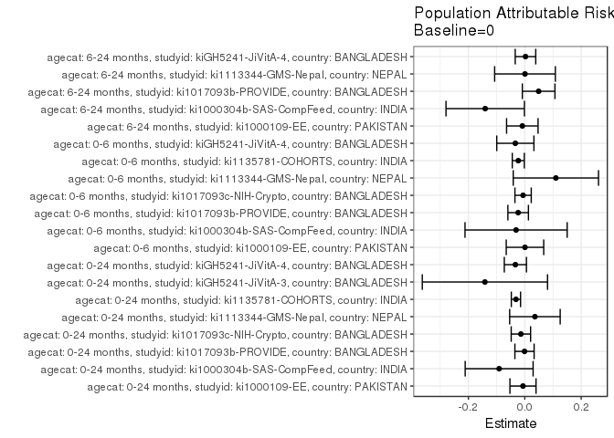

## Results Table

### Parameter: TSM

| agecat | studyid | country | intervention_level | baseline_level | estimate | ci_lower | ci_upper |
| --- | --- | --- | --- | --- | --- | --- | --- |
| 0-24 months | ki1000109-EE | PAKISTAN | 0 | NA | 0.4260355 | 0.3447151 | 0.5073559 |
| 0-24 months | ki1000109-EE | PAKISTAN | 1 | NA | 0.4069767 | 0.2968559 | 0.5170976 |
| 0-24 months | ki1000304b-SAS-CompFeed | INDIA | 0 | NA | 0.4687500 | 0.3418739 | 0.5956261 |
| 0-24 months | ki1000304b-SAS-CompFeed | INDIA | 1 | NA | 0.3682488 | 0.3281413 | 0.4083562 |
| 0-24 months | ki1017093b-PROVIDE | BANGLADESH | 0 | NA | 0.5840708 | 0.5180764 | 0.6500652 |
| 0-24 months | ki1017093b-PROVIDE | BANGLADESH | 1 | NA | 0.5802469 | 0.4690699 | 0.6914239 |
| 0-24 months | ki1017093c-NIH-Crypto | BANGLADESH | 0 | NA | 0.6376147 | 0.5719009 | 0.7033285 |
| 0-24 months | ki1017093c-NIH-Crypto | BANGLADESH | 1 | NA | 0.5913978 | 0.4963057 | 0.6864900 |
| 0-24 months | ki1113344-GMS-Nepal | NEPAL | 0 | NA | 0.4864865 | 0.3848752 | 0.5880978 |
| 0-24 months | ki1113344-GMS-Nepal | NEPAL | 1 | NA | 0.5323383 | 0.4799301 | 0.5847465 |
| 0-24 months | ki1135781-COHORTS | INDIA | 0 | NA | 0.2727273 | 0.2455889 | 0.2998656 |
| 0-24 months | ki1135781-COHORTS | INDIA | 1 | NA | 0.1992528 | 0.1723873 | 0.2261183 |
| 0-24 months | kiGH5241-JiVitA-3 | BANGLADESH | 0 | NA | 0.5833333 | 0.3560459 | 0.8106207 |
| 0-24 months | kiGH5241-JiVitA-3 | BANGLADESH | 1 | NA | 0.4273504 | 0.3351375 | 0.5195633 |
| 0-24 months | kiGH5241-JiVitA-4 | BANGLADESH | 0 | NA | 0.3105023 | 0.2642678 | 0.3567368 |
| 0-24 months | kiGH5241-JiVitA-4 | BANGLADESH | 1 | NA | 0.2662192 | 0.2420868 | 0.2903517 |
| 0-6 months | ki1000109-EE | PAKISTAN | 0 | NA | 0.5694444 | 0.4519225 | 0.6869663 |
| 0-6 months | ki1000109-EE | PAKISTAN | 1 | NA | 0.5714286 | 0.4056972 | 0.7371600 |
| 0-6 months | ki1000304b-SAS-CompFeed | INDIA | 0 | NA | 0.5416667 | 0.3534523 | 0.7298810 |
| 0-6 months | ki1000304b-SAS-CompFeed | INDIA | 1 | NA | 0.5078740 | 0.4454740 | 0.5702741 |
| 0-6 months | ki1017093b-PROVIDE | BANGLADESH | 0 | NA | 0.8115942 | 0.7470000 | 0.8761884 |
| 0-6 months | ki1017093b-PROVIDE | BANGLADESH | 1 | NA | 0.7173913 | 0.5887014 | 0.8460812 |
| 0-6 months | ki1017093c-NIH-Crypto | BANGLADESH | 0 | NA | 0.9000000 | 0.8497106 | 0.9502894 |
| 0-6 months | ki1017093c-NIH-Crypto | BANGLADESH | 1 | NA | 0.8793103 | 0.7944001 | 0.9642206 |
| 0-6 months | ki1113344-GMS-Nepal | NEPAL | 0 | NA | 0.4705882 | 0.3002632 | 0.6409133 |
| 0-6 months | ki1113344-GMS-Nepal | NEPAL | 1 | NA | 0.6090226 | 0.5257202 | 0.6923250 |
| 0-6 months | ki1135781-COHORTS | INDIA | 0 | NA | 0.3888889 | 0.3541245 | 0.4236533 |
| 0-6 months | ki1135781-COHORTS | INDIA | 1 | NA | 0.3298969 | 0.2880357 | 0.3717582 |
| 0-6 months | kiGH5241-JiVitA-4 | BANGLADESH | 0 | NA | 0.6394558 | 0.5617588 | 0.7171528 |
| 0-6 months | kiGH5241-JiVitA-4 | BANGLADESH | 1 | NA | 0.5921788 | 0.5412224 | 0.6431351 |
| 6-24 months | ki1000109-EE | PAKISTAN | 0 | NA | 0.3195876 | 0.2279106 | 0.4112647 |
| 6-24 months | ki1000109-EE | PAKISTAN | 1 | NA | 0.2941176 | 0.1610529 | 0.4271824 |
| 6-24 months | ki1000304b-SAS-CompFeed | INDIA | 0 | NA | 0.4250000 | 0.2781131 | 0.5718869 |
| 6-24 months | ki1000304b-SAS-CompFeed | INDIA | 1 | NA | 0.2689076 | 0.2212043 | 0.3166108 |
| 6-24 months | ki1017093b-PROVIDE | BANGLADESH | 0 | NA | 0.2272727 | 0.1407608 | 0.3137846 |
| 6-24 months | ki1017093b-PROVIDE | BANGLADESH | 1 | NA | 0.4000000 | 0.2229552 | 0.5770448 |
| 6-24 months | ki1113344-GMS-Nepal | NEPAL | 0 | NA | 0.4935065 | 0.3707222 | 0.6162908 |
| 6-24 months | ki1113344-GMS-Nepal | NEPAL | 1 | NA | 0.4944238 | 0.4305291 | 0.5583185 |
| 6-24 months | kiGH5241-JiVitA-4 | BANGLADESH | 0 | NA | 0.1443299 | 0.1023657 | 0.1862941 |
| 6-24 months | kiGH5241-JiVitA-4 | BANGLADESH | 1 | NA | 0.1475076 | 0.1259260 | 0.1690892 |

### Parameter: E(Y)

| agecat | studyid | country | intervention_level | baseline_level | estimate | ci_lower | ci_upper |
| --- | --- | --- | --- | --- | --- | --- | --- |
| 0-24 months | ki1000109-EE | PAKISTAN | NA | NA | 0.4196078 | 0.3541827 | 0.4850330 |
| 0-24 months | ki1000304b-SAS-CompFeed | INDIA | NA | NA | 0.3777778 | 0.3394240 | 0.4161316 |
| 0-24 months | ki1017093b-PROVIDE | BANGLADESH | NA | NA | 0.5830619 | 0.5262762 | 0.6398476 |
| 0-24 months | ki1017093c-NIH-Crypto | BANGLADESH | NA | NA | 0.6237942 | 0.5698223 | 0.6777662 |
| 0-24 months | ki1113344-GMS-Nepal | NEPAL | NA | NA | 0.5224172 | 0.4758292 | 0.5690051 |
| 0-24 months | ki1135781-COHORTS | INDIA | NA | NA | 0.2413610 | 0.2219406 | 0.2607813 |
| 0-24 months | kiGH5241-JiVitA-3 | BANGLADESH | NA | NA | 0.4418605 | 0.3551361 | 0.5285849 |
| 0-24 months | kiGH5241-JiVitA-4 | BANGLADESH | NA | NA | 0.2771220 | 0.2556194 | 0.2986246 |
| 0-6 months | ki1000109-EE | PAKISTAN | NA | NA | 0.5700935 | 0.4742263 | 0.6659606 |
| 0-6 months | ki1000304b-SAS-CompFeed | INDIA | NA | NA | 0.5107914 | 0.4514901 | 0.5700927 |
| 0-6 months | ki1017093b-PROVIDE | BANGLADESH | NA | NA | 0.7880435 | 0.7295878 | 0.8464992 |
| 0-6 months | ki1017093c-NIH-Crypto | BANGLADESH | NA | NA | 0.8939394 | 0.8505280 | 0.9373508 |
| 0-6 months | ki1113344-GMS-Nepal | NEPAL | NA | NA | 0.5808383 | 0.5055058 | 0.6561709 |
| 0-6 months | ki1135781-COHORTS | INDIA | NA | NA | 0.3658340 | 0.3390250 | 0.3926430 |
| 0-6 months | kiGH5241-JiVitA-4 | BANGLADESH | NA | NA | 0.6059406 | 0.5632798 | 0.6486014 |
| 6-24 months | ki1000109-EE | PAKISTAN | NA | NA | 0.3108108 | 0.2352987 | 0.3863229 |
| 6-24 months | ki1000304b-SAS-CompFeed | INDIA | NA | NA | 0.2846348 | 0.2390527 | 0.3302168 |
| 6-24 months | ki1017093b-PROVIDE | BANGLADESH | NA | NA | 0.2764228 | 0.1950773 | 0.3577682 |
| 6-24 months | ki1113344-GMS-Nepal | NEPAL | NA | NA | 0.4942197 | 0.4375393 | 0.5509000 |
| 6-24 months | kiGH5241-JiVitA-4 | BANGLADESH | NA | NA | 0.1467818 | 0.1275683 | 0.1659953 |

### Parameter: RR

| agecat | studyid | country | intervention_level | baseline_level | estimate | ci_lower | ci_upper |
| --- | --- | --- | --- | --- | --- | --- | --- |
| 0-24 months | ki1000109-EE | PAKISTAN | 0 | 0 | 1.0000000 | 1.0000000 | 1.0000000 |
| 0-24 months | ki1000109-EE | PAKISTAN | 1 | 0 | 0.9552649 | 0.6858937 | 1.3304261 |
| 0-24 months | ki1000304b-SAS-CompFeed | INDIA | 0 | 0 | 1.0000000 | 1.0000000 | 1.0000000 |
| 0-24 months | ki1000304b-SAS-CompFeed | INDIA | 1 | 0 | 0.7855974 | 0.5868019 | 1.0517404 |
| 0-24 months | ki1017093b-PROVIDE | BANGLADESH | 0 | 0 | 1.0000000 | 1.0000000 | 1.0000000 |
| 0-24 months | ki1017093b-PROVIDE | BANGLADESH | 1 | 0 | 0.9934530 | 0.7953971 | 1.2408254 |
| 0-24 months | ki1017093c-NIH-Crypto | BANGLADESH | 0 | 0 | 1.0000000 | 1.0000000 | 1.0000000 |
| 0-24 months | ki1017093c-NIH-Crypto | BANGLADESH | 1 | 0 | 0.9275161 | 0.7659250 | 1.1231988 |
| 0-24 months | ki1113344-GMS-Nepal | NEPAL | 0 | 0 | 1.0000000 | 1.0000000 | 1.0000000 |
| 0-24 months | ki1113344-GMS-Nepal | NEPAL | 1 | 0 | 1.0942510 | 0.8686441 | 1.3784532 |
| 0-24 months | ki1135781-COHORTS | INDIA | 0 | 0 | 1.0000000 | 1.0000000 | 1.0000000 |
| 0-24 months | ki1135781-COHORTS | INDIA | 1 | 0 | 0.7305936 | 0.6178743 | 0.8638764 |
| 0-24 months | kiGH5241-JiVitA-3 | BANGLADESH | 0 | 0 | 1.0000000 | 1.0000000 | 1.0000000 |
| 0-24 months | kiGH5241-JiVitA-3 | BANGLADESH | 1 | 0 | 0.7326007 | 0.4692527 | 1.1437415 |
| 0-24 months | kiGH5241-JiVitA-4 | BANGLADESH | 0 | 0 | 1.0000000 | 1.0000000 | 1.0000000 |
| 0-24 months | kiGH5241-JiVitA-4 | BANGLADESH | 1 | 0 | 0.8573826 | 0.7202330 | 1.0206487 |
| 0-6 months | ki1000109-EE | PAKISTAN | 0 | 0 | 1.0000000 | 1.0000000 | 1.0000000 |
| 0-6 months | ki1000109-EE | PAKISTAN | 1 | 0 | 1.0034843 | 0.7029104 | 1.4325876 |
| 0-6 months | ki1000304b-SAS-CompFeed | INDIA | 0 | 0 | 1.0000000 | 1.0000000 | 1.0000000 |
| 0-6 months | ki1000304b-SAS-CompFeed | INDIA | 1 | 0 | 0.9376136 | 0.6485807 | 1.3554507 |
| 0-6 months | ki1017093b-PROVIDE | BANGLADESH | 0 | 0 | 1.0000000 | 1.0000000 | 1.0000000 |
| 0-6 months | ki1017093b-PROVIDE | BANGLADESH | 1 | 0 | 0.8839286 | 0.7264161 | 1.0755953 |
| 0-6 months | ki1017093c-NIH-Crypto | BANGLADESH | 0 | 0 | 1.0000000 | 1.0000000 | 1.0000000 |
| 0-6 months | ki1017093c-NIH-Crypto | BANGLADESH | 1 | 0 | 0.9770115 | 0.8738707 | 1.0923258 |
| 0-6 months | ki1113344-GMS-Nepal | NEPAL | 0 | 0 | 1.0000000 | 1.0000000 | 1.0000000 |
| 0-6 months | ki1113344-GMS-Nepal | NEPAL | 1 | 0 | 1.2941729 | 0.8789283 | 1.9055975 |
| 0-6 months | ki1135781-COHORTS | INDIA | 0 | 0 | 1.0000000 | 1.0000000 | 1.0000000 |
| 0-6 months | ki1135781-COHORTS | INDIA | 1 | 0 | 0.8483063 | 0.7263434 | 0.9907484 |
| 0-6 months | kiGH5241-JiVitA-4 | BANGLADESH | 0 | 0 | 1.0000000 | 1.0000000 | 1.0000000 |
| 0-6 months | kiGH5241-JiVitA-4 | BANGLADESH | 1 | 0 | 0.9260668 | 0.7979593 | 1.0747412 |
| 6-24 months | ki1000109-EE | PAKISTAN | 0 | 0 | 1.0000000 | 1.0000000 | 1.0000000 |
| 6-24 months | ki1000109-EE | PAKISTAN | 1 | 0 | 0.9203036 | 0.5386238 | 1.5724495 |
| 6-24 months | ki1000304b-SAS-CompFeed | INDIA | 0 | 0 | 1.0000000 | 1.0000000 | 1.0000000 |
| 6-24 months | ki1000304b-SAS-CompFeed | INDIA | 1 | 0 | 0.6327237 | 0.4290456 | 0.9330925 |
| 6-24 months | ki1017093b-PROVIDE | BANGLADESH | 0 | 0 | 1.0000000 | 1.0000000 | 1.0000000 |
| 6-24 months | ki1017093b-PROVIDE | BANGLADESH | 1 | 0 | 1.7600000 | 0.9815984 | 3.1556693 |
| 6-24 months | ki1113344-GMS-Nepal | NEPAL | 0 | 0 | 1.0000000 | 1.0000000 | 1.0000000 |
| 6-24 months | ki1113344-GMS-Nepal | NEPAL | 1 | 0 | 1.0018587 | 0.7568662 | 1.3261537 |
| 6-24 months | kiGH5241-JiVitA-4 | BANGLADESH | 0 | 0 | 1.0000000 | 1.0000000 | 1.0000000 |
| 6-24 months | kiGH5241-JiVitA-4 | BANGLADESH | 1 | 0 | 1.0220171 | 0.7380855 | 1.4151735 |

### Parameter: PAR

| agecat | studyid | country | intervention_level | baseline_level | estimate | ci_lower | ci_upper |
| --- | --- | --- | --- | --- | --- | --- | --- |
| 0-24 months | ki1000109-EE | PAKISTAN | 0 | NA | -0.0064277 | -0.0526847 | 0.0398294 |
| 0-24 months | ki1000304b-SAS-CompFeed | INDIA | 0 | NA | -0.0909722 | -0.2114429 | 0.0294984 |
| 0-24 months | ki1017093b-PROVIDE | BANGLADESH | 0 | NA | -0.0010089 | -0.0351062 | 0.0330884 |
| 0-24 months | ki1017093c-NIH-Crypto | BANGLADESH | 0 | NA | -0.0138205 | -0.0482218 | 0.0205808 |
| 0-24 months | ki1113344-GMS-Nepal | NEPAL | 0 | NA | 0.0359307 | -0.0536762 | 0.1255376 |
| 0-24 months | ki1135781-COHORTS | INDIA | 0 | NA | -0.0313663 | -0.0477776 | -0.0149549 |
| 0-24 months | kiGH5241-JiVitA-3 | BANGLADESH | 0 | NA | -0.1414729 | -0.3635901 | 0.0806444 |
| 0-24 months | kiGH5241-JiVitA-4 | BANGLADESH | 0 | NA | -0.0333803 | -0.0726883 | 0.0059277 |
| 0-6 months | ki1000109-EE | PAKISTAN | 0 | NA | 0.0006490 | -0.0658124 | 0.0671104 |
| 0-6 months | ki1000304b-SAS-CompFeed | INDIA | 0 | NA | -0.0308753 | -0.2120406 | 0.1502900 |
| 0-6 months | ki1017093b-PROVIDE | BANGLADESH | 0 | NA | -0.0235507 | -0.0599719 | 0.0128705 |
| 0-6 months | ki1017093c-NIH-Crypto | BANGLADESH | 0 | NA | -0.0060606 | -0.0350005 | 0.0228793 |
| 0-6 months | ki1113344-GMS-Nepal | NEPAL | 0 | NA | 0.1102501 | -0.0409878 | 0.2614880 |
| 0-6 months | ki1135781-COHORTS | INDIA | 0 | NA | -0.0230549 | -0.0443811 | -0.0017287 |
| 0-6 months | kiGH5241-JiVitA-4 | BANGLADESH | 0 | NA | -0.0335152 | -0.0994110 | 0.0323806 |
| 6-24 months | ki1000109-EE | PAKISTAN | 0 | NA | -0.0087768 | -0.0645714 | 0.0470177 |
| 6-24 months | ki1000304b-SAS-CompFeed | INDIA | 0 | NA | -0.1403652 | -0.2794203 | -0.0013102 |
| 6-24 months | ki1017093b-PROVIDE | BANGLADESH | 0 | NA | 0.0491500 | -0.0086958 | 0.1069959 |
| 6-24 months | ki1113344-GMS-Nepal | NEPAL | 0 | NA | 0.0007132 | -0.1069217 | 0.1083480 |
| 6-24 months | kiGH5241-JiVitA-4 | BANGLADESH | 0 | NA | 0.0024519 | -0.0339565 | 0.0388603 |

### Parameter: PAF

| agecat | studyid | country | intervention_level | baseline_level | estimate | ci_lower | ci_upper |
| --- | --- | --- | --- | --- | --- | --- | --- |
| 0-24 months | ki1000109-EE | PAKISTAN | 0 | NA | -0.0153183 | -0.1317083 | 0.0891017 |
| 0-24 months | ki1000304b-SAS-CompFeed | INDIA | 0 | NA | -0.2408088 | -0.6052517 | 0.0408940 |
| 0-24 months | ki1017093b-PROVIDE | BANGLADESH | 0 | NA | -0.0017304 | -0.0619525 | 0.0550767 |
| 0-24 months | ki1017093c-NIH-Crypto | BANGLADESH | 0 | NA | -0.0221555 | -0.0787330 | 0.0314546 |
| 0-24 months | ki1113344-GMS-Nepal | NEPAL | 0 | NA | 0.0687777 | -0.1198009 | 0.2255990 |
| 0-24 months | ki1135781-COHORTS | INDIA | 0 | NA | -0.1299559 | -0.1993209 | -0.0646028 |
| 0-24 months | kiGH5241-JiVitA-3 | BANGLADESH | 0 | NA | -0.3201754 | -0.9499839 | 0.1062166 |
| 0-24 months | kiGH5241-JiVitA-4 | BANGLADESH | 0 | NA | -0.1204535 | -0.2711988 | 0.0124157 |
| 0-6 months | ki1000109-EE | PAKISTAN | 0 | NA | 0.0011384 | -0.1225208 | 0.1111751 |
| 0-6 months | ki1000304b-SAS-CompFeed | INDIA | 0 | NA | -0.0604460 | -0.4821519 | 0.2412750 |
| 0-6 months | ki1017093b-PROVIDE | BANGLADESH | 0 | NA | -0.0298851 | -0.0775203 | 0.0156444 |
| 0-6 months | ki1017093c-NIH-Crypto | BANGLADESH | 0 | NA | -0.0067797 | -0.0397071 | 0.0251050 |
| 0-6 months | ki1113344-GMS-Nepal | NEPAL | 0 | NA | 0.1898120 | -0.1195631 | 0.4136958 |
| 0-6 months | ki1135781-COHORTS | INDIA | 0 | NA | -0.0630201 | -0.1229865 | -0.0062558 |
| 0-6 months | kiGH5241-JiVitA-4 | BANGLADESH | 0 | NA | -0.0553110 | -0.1700349 | 0.0481640 |
| 6-24 months | ki1000109-EE | PAKISTAN | 0 | NA | -0.0282385 | -0.2249279 | 0.1368681 |
| 6-24 months | ki1000304b-SAS-CompFeed | INDIA | 0 | NA | -0.4931416 | -1.0785098 | -0.0726299 |
| 6-24 months | ki1017093b-PROVIDE | BANGLADESH | 0 | NA | 0.1778075 | -0.0510358 | 0.3568244 |
| 6-24 months | ki1113344-GMS-Nepal | NEPAL | 0 | NA | 0.0014430 | -0.2419243 | 0.1971201 |
| 6-24 months | kiGH5241-JiVitA-4 | BANGLADESH | 0 | NA | 0.0167043 | -0.2655766 | 0.2360239 |